# IODS course project

## Task 4

Here we need to standardize the dataset and print out summaries of the scaled data:

```r
boston_scaled <- scale(Boston)
summary(boston_scaled)
```

```
##       crim                 zn               indus              chas
##  Min.   :-0.419367   Min.   :-0.48724   Min.   :-1.5563   Min.   :-0.2723
##  1st Qu.:-0.410563   1st Qu.:-0.48724   1st Qu.:-0.8668   1st Qu.:-0.2723
##  Median :-0.390280   Median :-0.48724   Median :-0.2109   Median :-0.2723
##  Mean   : 0.000000   Mean   : 0.00000   Mean   : 0.0000   Mean   : 0.0000
##  3rd Qu.: 0.007389   3rd Qu.: 0.04872   3rd Qu.: 1.0150   3rd Qu.:-0.2723
##  Max.   : 9.924110   Max.   : 3.80047   Max.   : 2.4202   Max.   : 3.6648
##       nox                rm               age               dis
##  Min.   :-1.4644   Min.   :-3.8764   Min.   :-2.3331   Min.   :-1.2658
##  1st Qu.:-0.9121   1st Qu.:-0.5681   1st Qu.:-0.8366   1st Qu.:-0.8049
##  Median :-0.1441   Median :-0.1084   Median : 0.3171   Median :-0.2790
##  Mean   : 0.0000   Mean   : 0.0000   Mean   : 0.0000   Mean   : 0.0000
##  3rd Qu.: 0.5981   3rd Qu.: 0.4823   3rd Qu.: 0.9059   3rd Qu.: 0.6617
##  Max.   : 2.7296   Max.   : 3.5515   Max.   : 1.1164   Max.   : 3.9566
##       rad               tax             ptratio            black
##  Min.   :-0.9819   Min.   :-1.3127   Min.   :-2.7047   Min.   :-3.9033
##  1st Qu.:-0.6373   1st Qu.:-0.7668   1st Qu.:-0.4876   1st Qu.: 0.2049
##  Median :-0.5225   Median :-0.4642   Median : 0.2746   Median : 0.3808
##  Mean   : 0.0000   Mean   : 0.0000   Mean   : 0.0000   Mean   : 0.0000
##  3rd Qu.: 1.6596   3rd Qu.: 1.5294   3rd Qu.: 0.8058   3rd Qu.: 0.4332
##  Max.   : 1.6596   Max.   : 1.7964   Max.   : 1.6372   Max.   : 0.4406
##      lstat              medv
##  Min.   :-1.5296   Min.   :-1.9063
##  1st Qu.:-0.7986   1st Qu.:-0.5989
##  Median :-0.1811   Median :-0.1449
##  Mean   : 0.0000   Mean   : 0.0000
##  3rd Qu.: 0.6024   3rd Qu.: 0.2683
##  Max.   : 3.5453   Max.   : 2.9865
```

Now we can see that the distribution of the variables are centralized around the mean, which is 0, with a similar range of values.

In order to complete this task I will create a categorical variable of the crime rate from the scaled crime rate, using the quantiles as the break points in the categorical variable. But before doing that I need to change the object to a data frame. I will also drop the old crime rate variable from the dataset, add the new categorical value to scaled data, and divide it into train and test sets, so that 80% of the data belongs to the train set.

```r
boston_scaled <- as.data.frame(boston_scaled)
bins <- quantile(boston_scaled$crim)
crime <- cut(boston_scaled$crim, breaks = bins, include.lowest = TRUE, labels = c("low", "med_low", "med_high", "high"))
boston_scaled <- dplyr::select(boston_scaled, -crim)
boston_scaled <- data.frame(boston_scaled, crime)
n <- nrow(boston_scaled)
ind <- sample(n,  size = n * 0.8)
train <- boston_scaled[ind,]
test <- boston_scaled[-ind,]
```

## Task 5

Everything is ready now to fit the linear discriminant analysis on the train set. I will use the categorical crime rate as the target variable and all the other variables as predictor variables. A LDA (bi)plot will be performed to show the results.

```r
lda.fit <- lda(crime ~ ., data = train)
lda.fit
```

```
## Call:
## lda(crime ~ ., data = train)
##
## Prior probabilities of groups:
##       low   med_low  med_high      high
## 0.2673267 0.2574257 0.2351485 0.2400990
##
## Group means:
##                   zn      indus        chas        nox         rm        age
## low       0.90448020 -0.9030176 -0.12651054 -0.8607469  0.3975676 -0.8632312
## med_low  -0.06568373 -0.2504566  0.03052480 -0.5884344 -0.1450617 -0.4072407
## med_high -0.38704309  0.2514617  0.30787518  0.4134096  0.1205828  0.4373307
## high     -0.48724019  1.0172187 -0.02879709  1.0130287 -0.4103001  0.7835129
##                 dis        rad        tax     ptratio       black       lstat
## low       0.9095493 -0.6841205 -0.7481379 -0.41827085  0.37770619 -0.74251181
## med_low   0.4194874 -0.5489875 -0.4591926 -0.03098095  0.31179514 -0.14846233
## med_high -0.4253680 -0.3677436 -0.2534834 -0.31251882  0.09543593 -0.02355688
## high     -0.8505265  1.6371072  1.5133254  0.77958792 -0.80156168  0.84242416
##                 medv
## low       0.46950861
## med_low  -0.02395388
## med_high  0.17497888
## high     -0.62018873
##
## Coefficients of linear discriminants:
##                  LD1          LD2         LD3
## zn       0.096874171  0.577614313 -0.91068461
## indus    0.008919312 -0.308958419  0.41102516
## chas    -0.086458497 -0.060573737  0.13284154
## nox      0.390257904 -0.770472477 -1.22412777
## rm      -0.083568034 -0.139001480 -0.16157644
## age      0.328673038 -0.337478524 -0.24110491
## dis     -0.066670299 -0.196002233  0.20459780
## rad      2.974967009  0.884599845 -0.23383293
## tax      0.034309700  0.032488413  0.53512930
## ptratio  0.074795357  0.089743091 -0.14721960
## black   -0.146286324 -0.009716005  0.06140488
## lstat    0.181075319 -0.074974031  0.51779083
## medv     0.177317376 -0.299912896 -0.02837278
##
## Proportion of trace:
##    LD1    LD2    LD3
## 0.9460 0.0391 0.0149
```

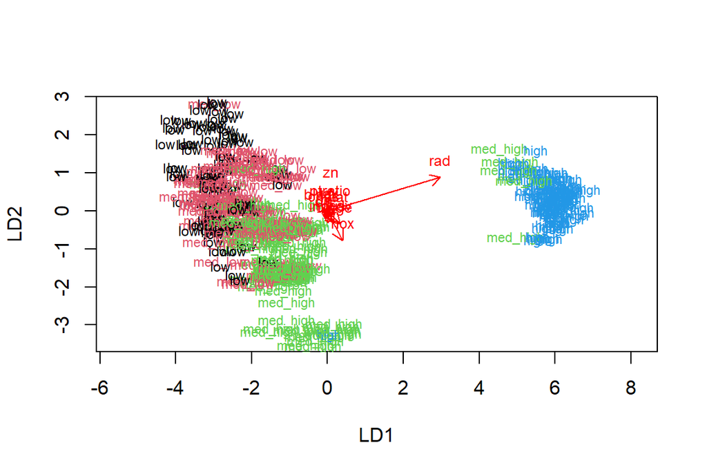

```r
lda.arrows <- function(x, myscale = 1, arrow_heads = 0.1, color = "red", tex = 0.75, choices = c(1,2)){
  heads <- coef(x)
  arrows(x0 = 0, y0 = 0,
         x1 = myscale * heads[,choices[1]],
         y1 = myscale * heads[,choices[2]], col=color, length = arrow_heads)
  text(myscale * heads[,choices], labels = row.names(heads),
       cex = tex, col=color, pos=3)
}
classes <- as.numeric(train$crime)
plot(lda.fit, dimen = 2, col = classes, pch = classes)
lda.arrows(lda.fit, myscale = 1)
```

## Task 6

In this task I will save the crime categories from the test set and then remove the categorical crime variable from the test dataset. Also I need to predict the classes with the LDA model on the test data and cross tabulate the results with the crime categories from the test set.

```r
correct_classes <- test$crime
test <- dplyr::select(test, -crime)
lda.pred <- predict(lda.fit, newdata = test)
table(correct = correct_classes, predicted = lda.pred$class)
```

```
##           predicted
## correct    low med_low med_high high
##   low       16       3        0    0
##   med_low    2      14        6    0
##   med_high   0      18       13    0
##   high       0       0        0   30
```